# Chapter 3 Preliminary visualizations

## 3.1 Filtering and normalization

```r
# Create edgeR DGEList
dge <- DGEList(counts = read_counts)

# Filter lowly expressed genes (keep genes with CPM>1 in at least 2 samples)
keep <- rowSums(cpm(dge) > 1) >= 2
dge <- dge[keep, , keep.lib.sizes = FALSE]

# Normalize for library size (TMM normalization)
dge <- calcNormFactors(dge)

# Log2 CPM transformation
logCPM <- cpm(dge, log = TRUE, prior.count = 1)  # log2(CPM + 1)
```

## 3.2 Preliminary visualizations

### 3.2.1 Library size plot

In this plot we see a fold difference of 3-4X between the samples with the lowest number of reads and the samples with the highest number of reads. Most of the difference is between the 3 h samples (higher expression, exponential growth curve) and 24 h samples (lower expression, stationary phase). At 24 h DREX protocol seems yield more RNA than most of Zymo samples. Goethite samples at 3 h -(except DREX sample) have less reads than the rest of 3 h samples, which agrees with the concentrations calculated with Qubit. We expect some cell death in goethite at 3 h.

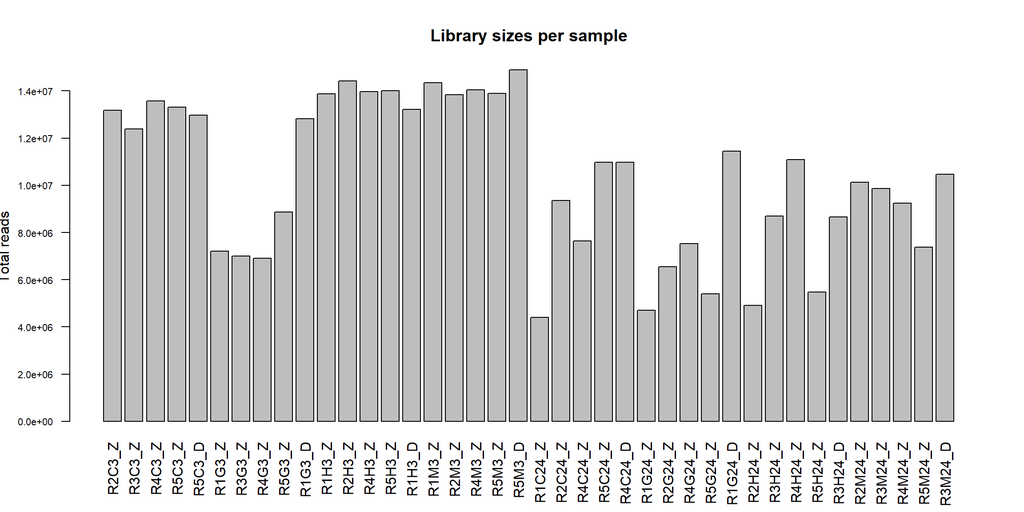

```r
# Total reads per sample (wihtout filtering and normalizing)
lib_sizes <- colSums(read_counts)

par(mgp = c(3.4, 1, 0))

barplot(lib_sizes,
        las = 2,
        cex.axis = 0.7,
        ylab = "Total reads",
        main = "Library sizes per sample")
```

### 3.2.2 Box plots of transformed counts

Most of the samples processed with DREX protocol show narrower distributions (reads are more evenly distributed across genes), is this good or bad?

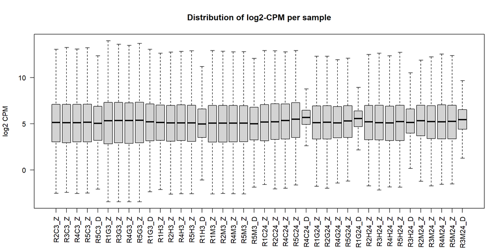

```r
boxplot(logCPM,
        las = 2,
        outline = FALSE,
        ylab = "log2 CPM",
        main = "Distribution of log2-CPM per sample")
```

### 3.2.3 Hierarchical clustering

The clustering separates each mineral sample quite good at 3 h, but not that good at 24 h (except for goethite)

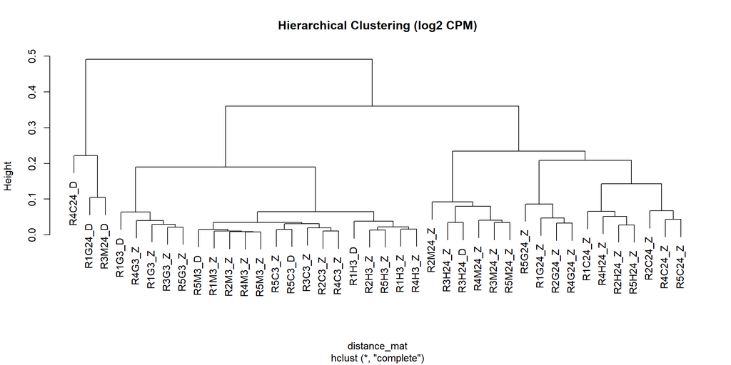

```r
distance_mat <- as.dist(1 - cor(logCPM))  # Pearson correlation distance
hclust_res <- hclust(distance_mat, method = "complete")
plot(hclust_res, labels = colnames(logCPM), main = "Hierarchical Clustering (log2 CPM)")
```

### 3.2.4 Sample-sample distance heatmap

Distance calculation is the same as the previous one but here with all the metadata and pairwise distances visible

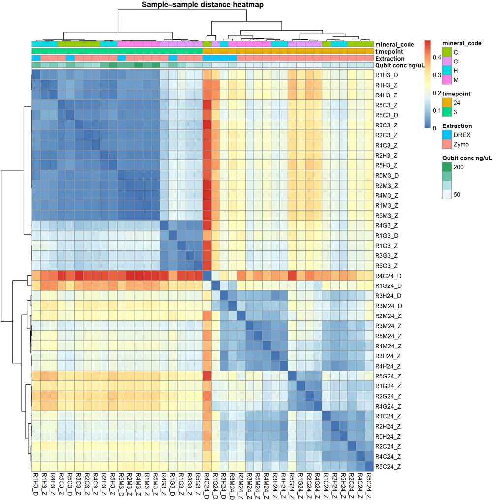

```r
heatmap_metadata <- sample_metadata %>%
  dplyr::select(`Qubit conc ng/uL`, Extraction, timepoint, mineral_code)

sample_dist <- as.matrix(distance_mat)

pheatmap(sample_dist,
         # cluster_rows = hclust_res,
         # cluster_cols = hclust_res,
         annotation_col = heatmap_metadata,
         main = "Sample–sample distance heatmap",
         clustering_distance_cols = "correlation",
         clustering_distance_rows = "correlation")
```

### 3.2.5 PCA

In the PCA there are some interesting observations:

- The first PC explains most of the variance in the samples and it clearly separates the samples at 3 h and 24 h for all the minerals and RNA extraction protocols.
- PC2 captures some of the variance between samples processed with DREX at 24 h. It seems for samples at 3 h the extraction protocol did not have that effect.
- PC2 and especially PC3 caputres some of the variance that differentiates the goethite samples at 3 h (maybe stress response?)

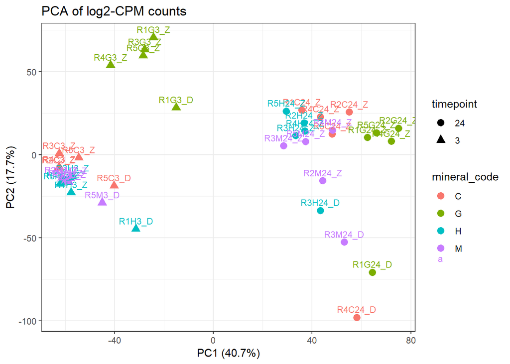

```r
pca_res <- prcomp(t(logCPM))  # samples as rows
pca_scores <- as.data.frame(pca_res$x) %>%
  tibble::rownames_to_column("sample_pca")

pca_metadata <- sample_metadata %>%
  tibble::rownames_to_column("sample_pca")

pca_df <- pca_scores %>%
  dplyr::left_join(pca_metadata, by = "sample_pca")


# Calculate percent of variance explained
# Variance explained per PC
pca_var <- pca_res$sdev^2
pca_var_frac <- pca_var / sum(pca_var)

# Percent variance explained
pca_var_pct <- round(100 * pca_var_frac, 1)


ggplot(pca_df, aes(x = PC1, y = PC2,
                   color = mineral_code,
                   shape = timepoint)) +
  geom_point(size = 3) +
  geom_text(aes(label = sample_pca), vjust = -0.7, size = 3) +
  theme_bw() +
  labs(
    title = "PCA of log2-CPM counts",
    x = paste0("PC1 (", pca_var_pct[1], "%)"),
    y = paste0("PC2 (", pca_var_pct[2], "%)")
  )
```

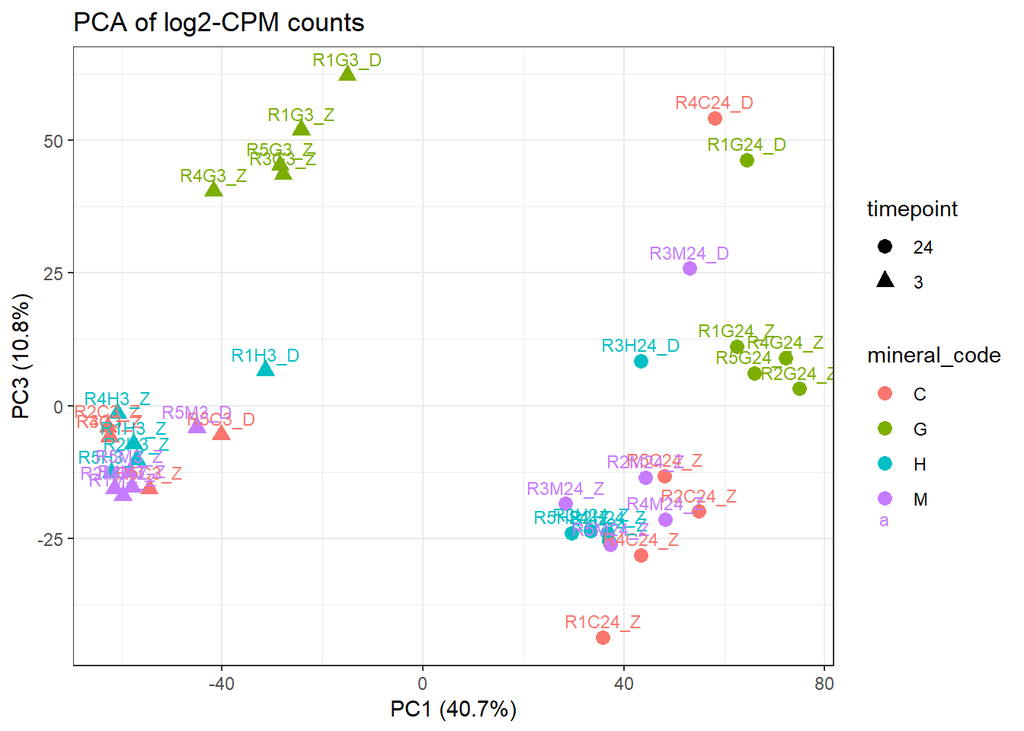

```r
ggplot(pca_df, aes(x = PC1, y = PC3,
                   color = mineral_code,
                   shape = timepoint)) +
  geom_point(size = 3) +
  geom_text(aes(label = sample_pca), vjust = -0.7, size = 3) +
  theme_bw() +
  labs(
    title = "PCA of log2-CPM counts",
    x = paste0("PC1 (", pca_var_pct[1], "%)"),
    y = paste0("PC3 (", pca_var_pct[3], "%)")
  )
```

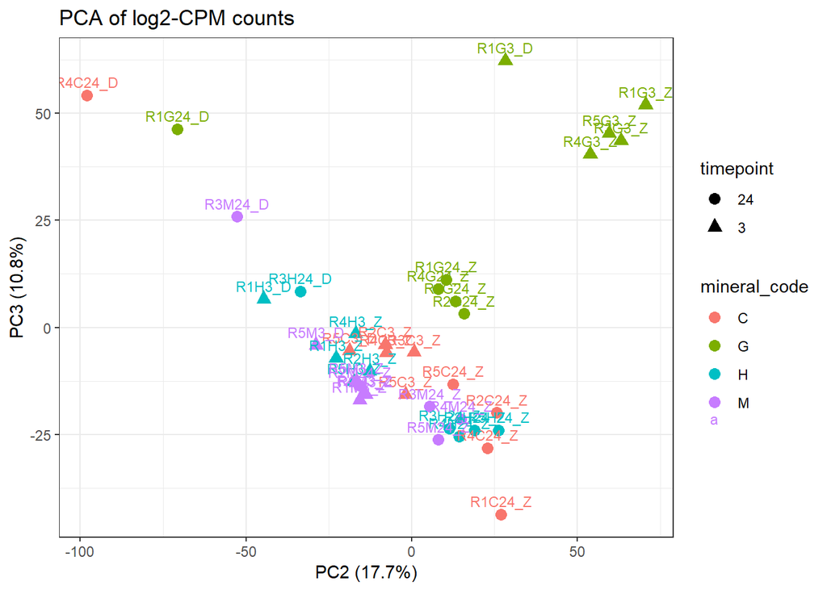

```r
ggplot(pca_df, aes(x = PC2, y = PC3,
                   color = mineral_code,
                   shape = timepoint)) +
  geom_point(size = 3) +
  geom_text(aes(label = sample_pca), vjust = -0.7, size = 3) +
  theme_bw() +
  labs(
    title = "PCA of log2-CPM counts",
    x = paste0("PC2 (", pca_var_pct[2], "%)"),
    y = paste0("PC3 (", pca_var_pct[3], "%)")
  )
```

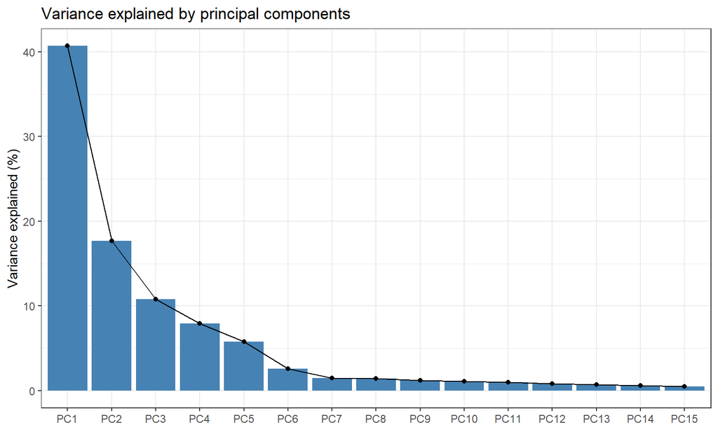

```r
pca_var_df <- data.frame(
  PC = factor(paste0("PC", seq_along(pca_var_pct)),
              levels = paste0("PC", seq_along(pca_var_pct))),
  variance = pca_var_pct
)

ggplot(pca_var_df[1:15, ], aes(x = PC, y = variance)) +
  geom_col(fill = "steelblue") +
  geom_line(aes(group = 1)) +
  geom_point() +
  theme_bw() +
  labs(
    title = "Variance explained by principal components",
    y = "Variance explained (%)",
    x = ""
  )
```

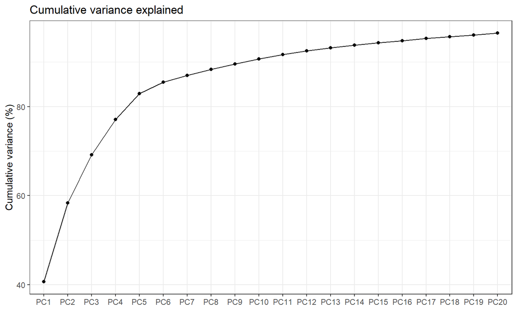

```r
pca_var_df$cumulative <- cumsum(pca_var_df$variance)

ggplot(pca_var_df[1:20, ], aes(x = PC, y = cumulative)) +
  geom_line(group = 1) +
  geom_point() +
  theme_bw() +
  labs(
    title = "Cumulative variance explained",
    y = "Cumulative variance (%)",
    x = ""
  )
```

### 3.2.6 PERMANOVA and dispersion test

Here we do PERMANOVA using the option “terms” that adds predictors one at a time, in order, and seeing how much extra variation each of them adds.

y ~ timepoint * mineral is the same as y ~ timepoint + mineral + timepoint:mineral

```r
# Distance matrix
dist_mat <- as.dist(1 - cor(logCPM, method = "pearson"))

# by = "terms" means adonis2 tests terms in order, like Type I sums of squares in ANOVA. The differences between terms and margin are not very important when you have balanced samples like we have here.
# Permanova
perm_res <- adonis2(
  dist_mat ~ timepoint * mineral_code,
  data = sample_metadata,
  permutations = 999,
  by = "terms"
)


# Nice table
perm_table <- as.data.frame(perm_res) %>%
  rownames_to_column("term")

perm_table
```

```
                    term Df   SumOfSqs         R2         F Pr(>F)
1              timepoint  1 0.46814880 0.55480841 95.781150  0.001
2           mineral_code  3 0.15978610 0.18936431 10.897174  0.001
3 timepoint:mineral_code  3 0.05946157 0.07046858  4.055191  0.003
4               Residual 32 0.15640616 0.18535870        NA     NA
5                  Total 39 0.84380264 1.00000000        NA     NA
```

```r
# Create combined group factor: timepoint:mineral
sample_metadata <- sample_metadata %>%
  mutate(group = interaction(timepoint, mineral_code, drop = TRUE))

bd_group <- betadisper(dist_mat, sample_metadata$group)
disp_group <- anova(bd_group)

bd_time <- betadisper(dist_mat, sample_metadata$timepoint)
bd_mineral <- betadisper(dist_mat, sample_metadata$mineral_code)

disp_time <- anova(bd_time)
disp_mineral <- anova(bd_mineral)


disp_table <- bind_rows(
  data.frame(test = "Dispersion: timepoint",
             F = disp_time$`F value`[1],
             p = disp_time$`Pr(>F)`[1]),
  data.frame(test = "Dispersion: mineral",
             F = disp_mineral$`F value`[1],
             p = disp_mineral$`Pr(>F)`[1]),
  data.frame(test = "Dispersion: timepoint:mineral",
             F = disp_group$`F value`[1],
             p = disp_group$`Pr(>F)`[1])
) %>%
  mutate(
    F = round(F, 3),
    p = signif(p, 3)
  )

disp_table
```

```
                           test     F      p
1         Dispersion: timepoint 7.091 0.0113
2           Dispersion: mineral 0.663 0.5800
3 Dispersion: timepoint:mineral 1.460 0.2170
```

```r
final_table <- perm_table %>%
  dplyr::select(term, Df, F, R2, `Pr(>F)`) %>%
  dplyr::rename(p = `Pr(>F)`)

final_table
```

```
                    term Df         F         R2     p
1              timepoint  1 95.781150 0.55480841 0.001
2           mineral_code  3 10.897174 0.18936431 0.001
3 timepoint:mineral_code  3  4.055191 0.07046858 0.003
4               Residual 32        NA 0.18535870    NA
5                  Total 39        NA 1.00000000    NA
```

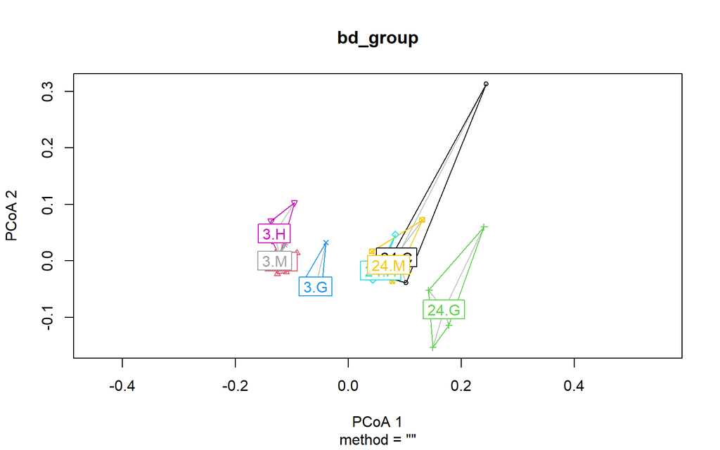

```r
plot(bd_group)
```

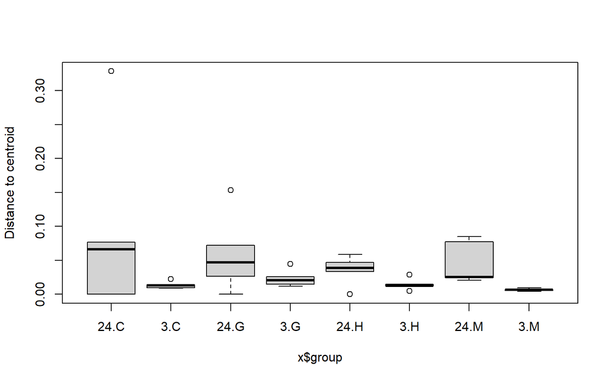

```r
boxplot(bd_group)
```

## 3.3 Preliminary visualizations wo DREX group

We plot some of the same visualizations after removing the DREX samples.

### 3.3.1 Filtering DREX group, filtering and normalization

```r
# Create edgeR DGEList
dge <- DGEList(counts = counts_wo_drex)

# Filter lowly expressed genes (keep genes with CPM>1 in at least 2 samples)
keep <- rowSums(cpm(dge) > 1) >= 2
dge <- dge[keep, , keep.lib.sizes = FALSE]

# Normalize for library size (TMM normalization)
dge <- calcNormFactors(dge)

# Log2 CPM transformation
logCPM <- cpm(dge, log = TRUE, prior.count = 1)  # log2(CPM + 1)
```

### 3.3.2 Hierarchical clustering

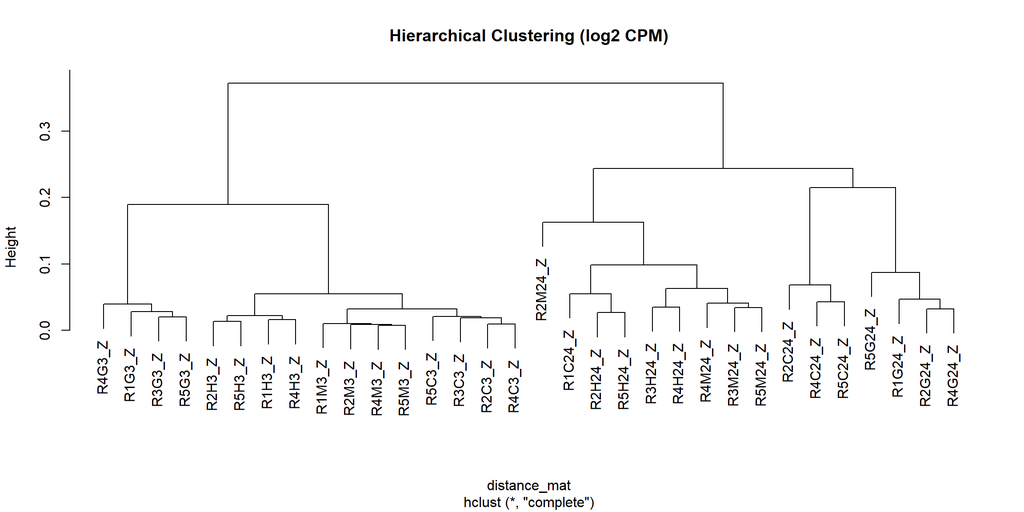

```r
distance_mat <- as.dist(1 - cor(logCPM))  # Pearson correlation distance
hclust_res <- hclust(distance_mat, method = "complete")
plot(hclust_res, labels = colnames(logCPM), main = "Hierarchical Clustering (log2 CPM)")
```

### 3.3.3 Sample-sample distance heatmap

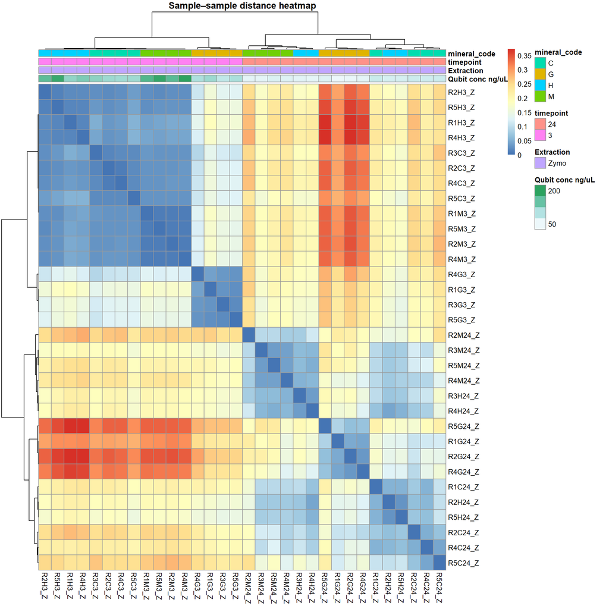

```r
heatmap_metadata <- metadata_wo_drex %>%
  dplyr::select(`Qubit conc ng/uL`, Extraction, timepoint, mineral_code)


sample_dist <- as.matrix(distance_mat)

pheatmap(sample_dist,
         # cluster_rows = hclust_res,
         # cluster_cols = hclust_res,
         annotation_col = heatmap_metadata,
         main = "Sample–sample distance heatmap",
         clustering_distance_cols = "correlation",
         clustering_distance_rows = "correlation")
```

### 3.3.4 PCA

Observations after removing the DREX samples:

- PC1 keeps capturing the variance related to the timepoint of sample collection.
- PC2 clearly separates the goetihte smaples at 3 h and a little bit at 24 h, some of the expression pattern in goethite is quite different at the beginning and the difference start fading after 24 h.
- PC3 separates the goethite samples at 24 h but not at 3 h.
- PC4 separates the controls at 24 h

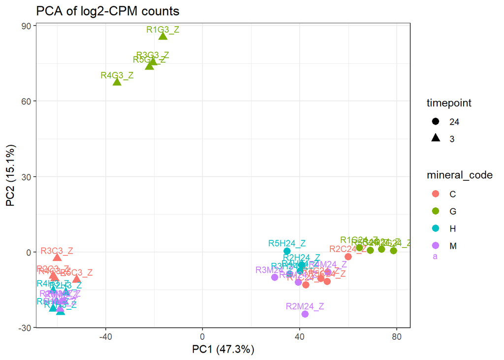

```r
pca_res <- prcomp(t(logCPM))  # samples as rows
pca_scores <- as.data.frame(pca_res$x) %>%
  tibble::rownames_to_column("sample_pca")

pca_metadata <- metadata_wo_drex %>%
  tibble::rownames_to_column("sample_pca")

pca_df <- pca_scores %>%
  dplyr::left_join(pca_metadata, by = "sample_pca")


# Calculate percent of variance explained
# Variance explained per PC
pca_var <- pca_res$sdev^2
pca_var_frac <- pca_var / sum(pca_var)

# Percent variance explained
pca_var_pct <- round(100 * pca_var_frac, 1)


ggplot(pca_df, aes(x = PC1, y = PC2,
                   color = mineral_code,
                   shape = timepoint)) +
  geom_point(size = 3) +
  geom_text(aes(label = sample_pca), vjust = -0.7, size = 3) +
  theme_bw() +
  labs(
    title = "PCA of log2-CPM counts",
    x = paste0("PC1 (", pca_var_pct[1], "%)"),
    y = paste0("PC2 (", pca_var_pct[2], "%)")
  )
```

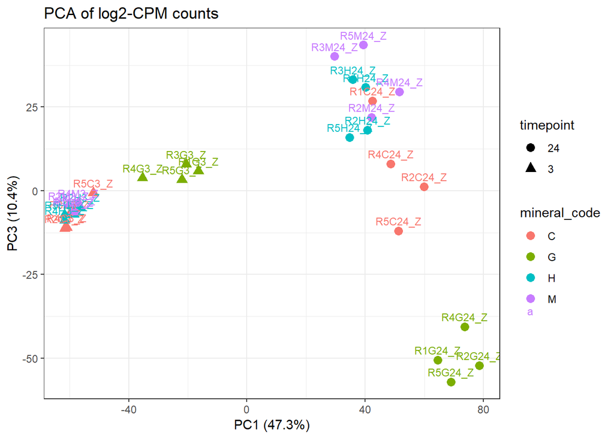

```r
ggplot(pca_df, aes(x = PC1, y = PC3,
                   color = mineral_code,
                   shape = timepoint)) +
  geom_point(size = 3) +
  geom_text(aes(label = sample_pca), vjust = -0.7, size = 3) +
  theme_bw() +
  labs(
    title = "PCA of log2-CPM counts",
    x = paste0("PC1 (", pca_var_pct[1], "%)"),
    y = paste0("PC3 (", pca_var_pct[3], "%)")
  )
```

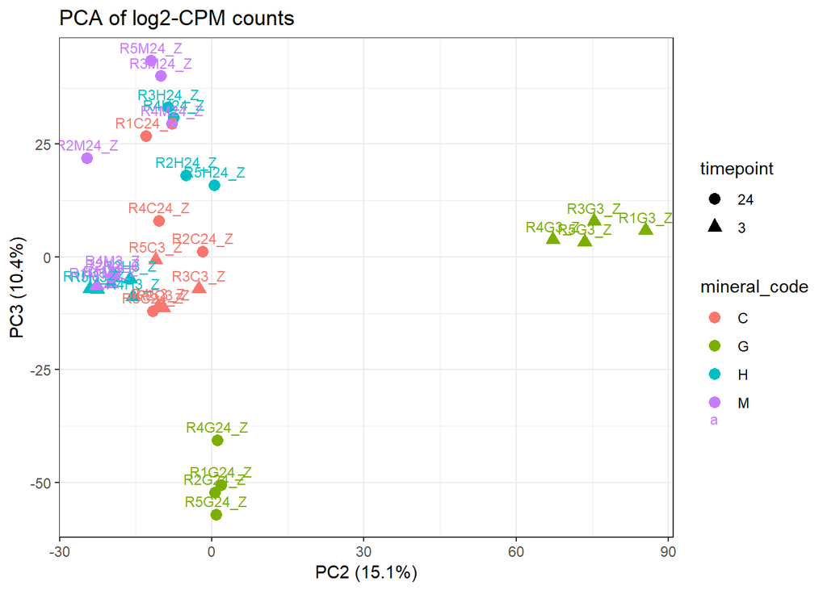

```r
ggplot(pca_df, aes(x = PC2, y = PC3,
                   color = mineral_code,
                   shape = timepoint)) +
  geom_point(size = 3) +
  geom_text(aes(label = sample_pca), vjust = -0.7, size = 3) +
  theme_bw() +
  labs(
    title = "PCA of log2-CPM counts",
    x = paste0("PC2 (", pca_var_pct[2], "%)"),
    y = paste0("PC3 (", pca_var_pct[3], "%)")
  )
```

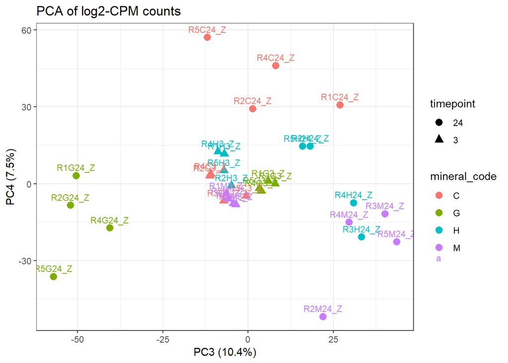

```r
ggplot(pca_df, aes(x = PC3, y = PC4,
                   color = mineral_code,
                   shape = timepoint)) +
  geom_point(size = 3) +
  geom_text(aes(label = sample_pca), vjust = -0.7, size = 3) +
  theme_bw() +
  labs(
    title = "PCA of log2-CPM counts",
    x = paste0("PC3 (", pca_var_pct[3], "%)"),
    y = paste0("PC4 (", pca_var_pct[4], "%)")
  )
```

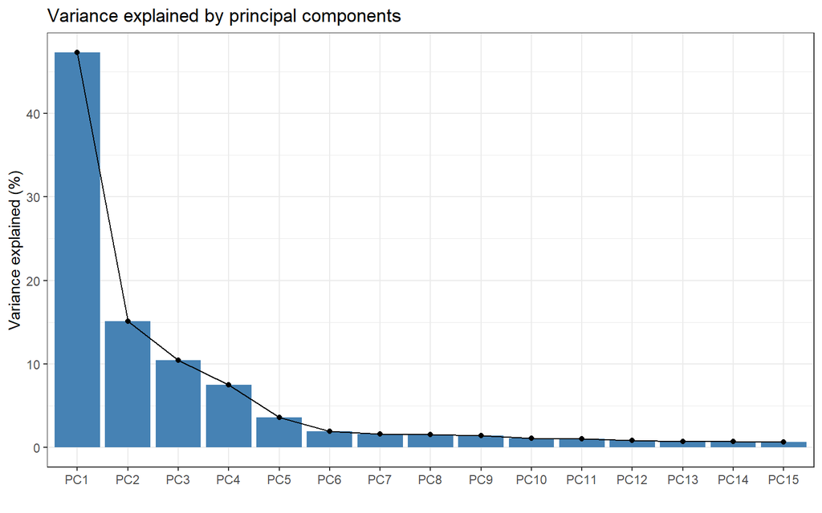

```r
pca_var_df <- data.frame(
  PC = factor(paste0("PC", seq_along(pca_var_pct)),
              levels = paste0("PC", seq_along(pca_var_pct))),
  variance = pca_var_pct
)

ggplot(pca_var_df[1:15, ], aes(x = PC, y = variance)) +
  geom_col(fill = "steelblue") +
  geom_line(aes(group = 1)) +
  geom_point() +
  theme_bw() +
  labs(
    title = "Variance explained by principal components",
    y = "Variance explained (%)",
    x = ""
  )
```

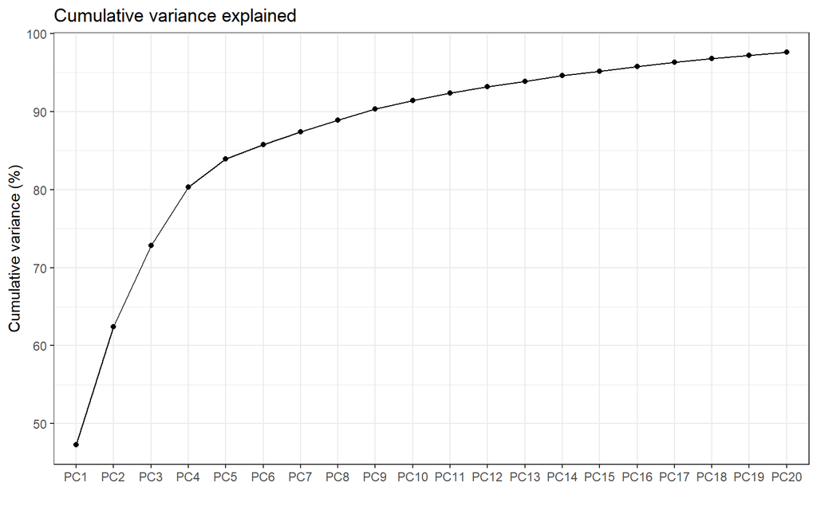

```r
pca_var_df$cumulative <- cumsum(pca_var_df$variance)

ggplot(pca_var_df[1:20, ], aes(x = PC, y = cumulative)) +
  geom_line(group = 1) +
  geom_point() +
  theme_bw() +
  labs(
    title = "Cumulative variance explained",
    y = "Cumulative variance (%)",
    x = ""
  )
```

### 3.3.5 PERMANOVA and dispersion test

```r
# Create edgeR DGEList
dge <- DGEList(counts = counts_wo_drex)

# Filter lowly expressed genes (keep genes with CPM>1 in at least 2 samples)
keep <- rowSums(cpm(dge) > 1) >= 2
dge <- dge[keep, , keep.lib.sizes = FALSE]

# Normalize for library size (TMM normalization)
dge <- calcNormFactors(dge)

# Log2 CPM transformation
logCPM <- cpm(dge, log = TRUE, prior.count = 1)  # log2(CPM + 1)

# Distance matrix
dist_mat <- as.dist(1 - cor(logCPM, method = "pearson"))

# by = "terms" means adonis2 tests terms in order, like Type I sums of squares in ANOVA
# Permanova
perm_res <- adonis2(
  dist_mat ~ timepoint * mineral_code,
  data = metadata_wo_drex,
  permutations = 999,
  by = "terms"
)


# Nice table
perm_table <- as.data.frame(perm_res) %>%
  rownames_to_column("term")

perm_table
```

```
                    term Df   SumOfSqs         R2          F Pr(>F)
1              timepoint  1 0.37113609 0.65935109 332.457894  0.001
2           mineral_code  3 0.13154087 0.23369223  39.277419  0.001
3 timepoint:mineral_code  3 0.03341171 0.05935840   9.976561  0.001
4               Residual 24 0.02679216 0.04759829         NA     NA
5                  Total 31 0.56288083 1.00000000         NA     NA
```

```r
# Create combined group factor: timepoint:mineral
metadata_wo_drex <- metadata_wo_drex %>%
  mutate(group = interaction(timepoint, mineral_code, drop = TRUE))

bd_group <- betadisper(dist_mat, metadata_wo_drex$group)
disp_group <- anova(bd_group)


bd_time <- betadisper(dist_mat, metadata_wo_drex$timepoint)
bd_mineral <- betadisper(dist_mat, metadata_wo_drex$mineral_code)

disp_time <- anova(bd_time)
disp_mineral <- anova(bd_mineral)


disp_table <- bind_rows(
  data.frame(test = "Dispersion: timepoint",
             F = disp_time$`F value`[1],
             p = disp_time$`Pr(>F)`[1]),
  data.frame(test = "Dispersion: mineral",
             F = disp_mineral$`F value`[1],
             p = disp_mineral$`Pr(>F)`[1]),
  data.frame(test = "Dispersion: timepoint:mineral",
             F = disp_group$`F value`[1],
             p = disp_group$`Pr(>F)`[1])
) %>%
  mutate(
    F = round(F, 3),
    p = signif(p, 3)
  )

disp_table
```

```
                           test     F      p
1         Dispersion: timepoint 4.764 0.0370
2           Dispersion: mineral 0.370 0.7750
3 Dispersion: timepoint:mineral 2.609 0.0374
```

```r
final_table <- perm_table %>%
  dplyr::select(term, Df, F, R2, `Pr(>F)`) %>%
  dplyr::rename(p = `Pr(>F)`)

final_table
```

```
                    term Df          F         R2     p
1              timepoint  1 332.457894 0.65935109 0.001
2           mineral_code  3  39.277419 0.23369223 0.001
3 timepoint:mineral_code  3   9.976561 0.05935840 0.001
4               Residual 24         NA 0.04759829    NA
5                  Total 31         NA 1.00000000    NA
```

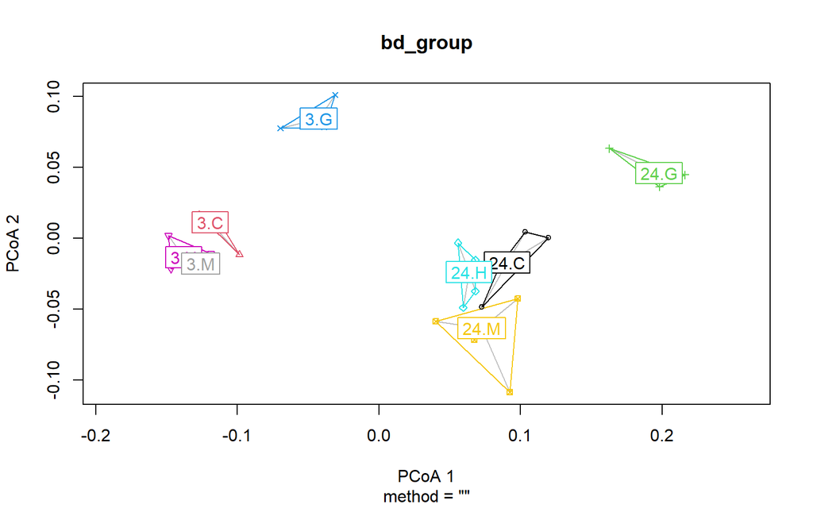

```r
plot(bd_group)
```

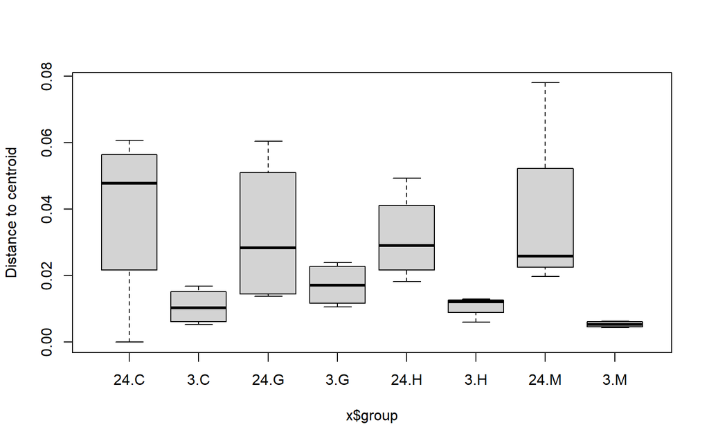

```r
boxplot(bd_group)
```

## 3.4 Other PCAs

### 3.4.1 Samples at 3h

Here we check PCAs information by subsetting the data in different groups. First we look at PCA of samples at 3h.

- At 3h most of the variation separates goethite from the rest of the samples (PC1).
- PC2 separates some of the minerals, but not completely. The PC3 separates the minerals quite well, especially mica and the control. It keeps goethite and hematite together. This is interesting because these two are both iron oxides and there might be some biological meaning behind this.

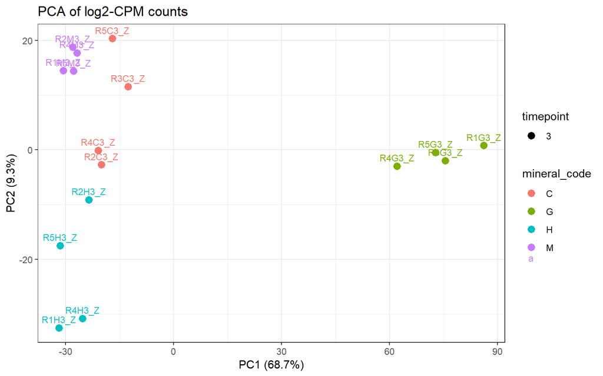

```r
# Filter out samples processed using DREX protocol and keep only samples at 3h
read_counts_3h <- read_counts %>%
  dplyr::select(-ends_with("D")) %>%
  dplyr::select((matches("3_")))

# Create edgeR DGEList
dge <- DGEList(counts = read_counts_3h)

# Filter lowly expressed genes (keep genes with CPM>1 in at least 2 samples)
keep <- rowSums(cpm(dge) > 1) >= 2
dge <- dge[keep, , keep.lib.sizes = FALSE]

# Normalize for library size (TMM normalization)
dge <- calcNormFactors(dge)

# Log2 CPM transformation
logCPM <- cpm(dge, log = TRUE, prior.count = 1)  # log2(CPM + 1)



pca_res <- prcomp(t(logCPM))  # samples as rows
pca_scores <- as.data.frame(pca_res$x) %>%
  tibble::rownames_to_column("sample_pca")

pca_metadata <- sample_metadata %>%
  tibble::rownames_to_column("sample_pca")

pca_df <- pca_scores %>%
  dplyr::left_join(pca_metadata, by = "sample_pca")


# Calculate percent of variance explained
# Variance explained per PC
pca_var <- pca_res$sdev^2
pca_var_frac <- pca_var / sum(pca_var)

# Percent variance explained
pca_var_pct <- round(100 * pca_var_frac, 1)


ggplot(pca_df, aes(x = PC1, y = PC2,
                   color = mineral_code,
                   shape = timepoint)) +
  geom_point(size = 3) +
  geom_text(aes(label = sample_pca), vjust = -0.7, size = 3) +
  theme_bw() +
  labs(
    title = "PCA of log2-CPM counts",
    x = paste0("PC1 (", pca_var_pct[1], "%)"),
    y = paste0("PC2 (", pca_var_pct[2], "%)")
  )
```

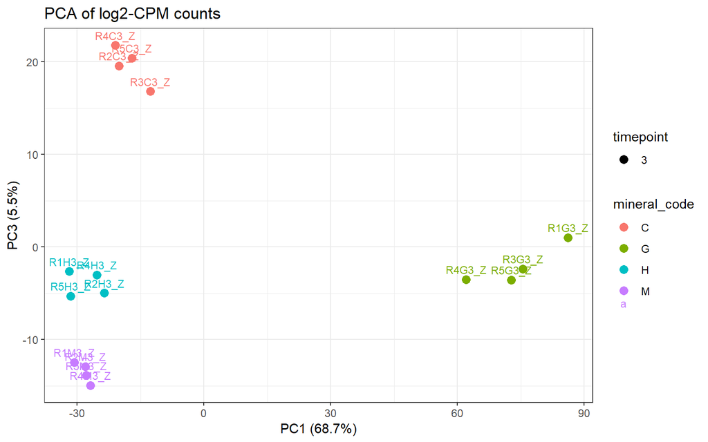

```r
ggplot(pca_df, aes(x = PC1, y = PC3,
                   color = mineral_code,
                   shape = timepoint)) +
  geom_point(size = 3) +
  geom_text(aes(label = sample_pca), vjust = -0.7, size = 3) +
  theme_bw() +
  labs(
    title = "PCA of log2-CPM counts",
    x = paste0("PC1 (", pca_var_pct[1], "%)"),
    y = paste0("PC3 (", pca_var_pct[3], "%)")
  )
```

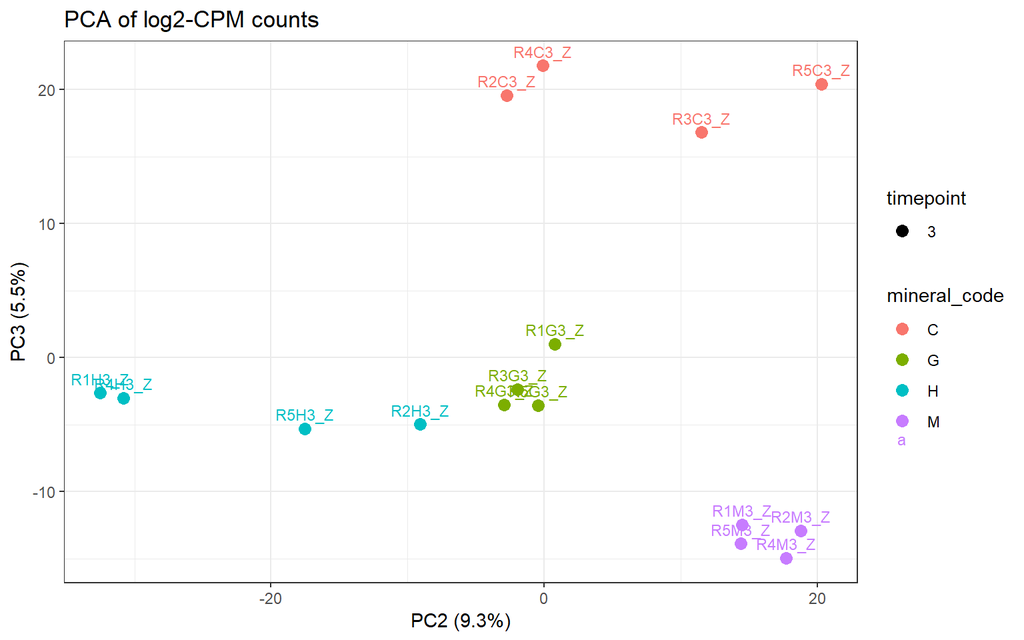

```r
ggplot(pca_df, aes(x = PC2, y = PC3,
                   color = mineral_code,
                   shape = timepoint)) +
  geom_point(size = 3) +
  geom_text(aes(label = sample_pca), vjust = -0.7, size = 3) +
  theme_bw() +
  labs(
    title = "PCA of log2-CPM counts",
    x = paste0("PC2 (", pca_var_pct[2], "%)"),
    y = paste0("PC3 (", pca_var_pct[3], "%)")
  )
```

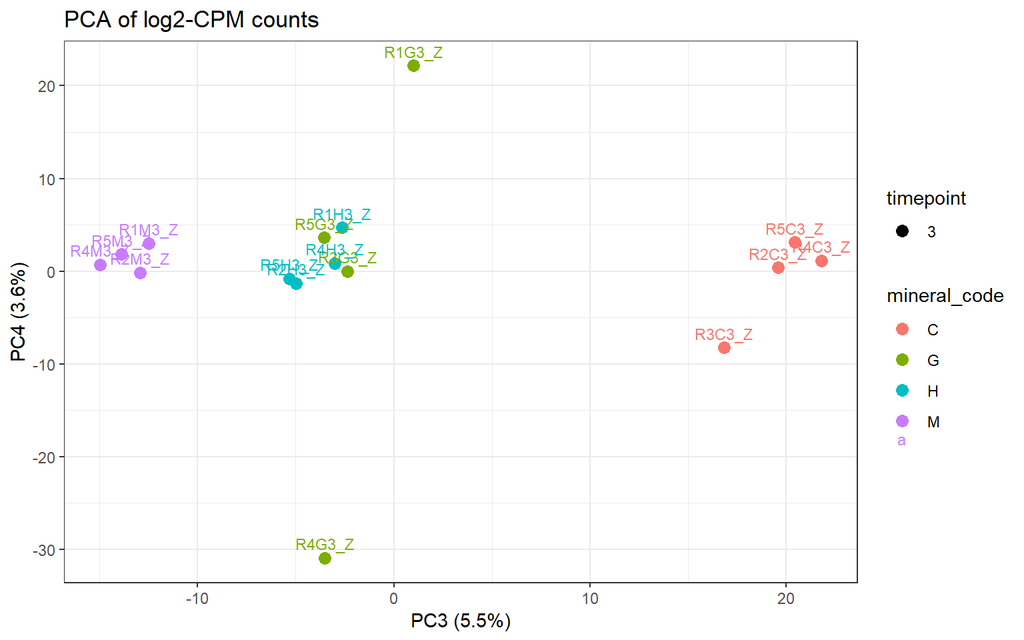

```r
ggplot(pca_df, aes(x = PC3, y = PC4,
                   color = mineral_code,
                   shape = timepoint)) +
  geom_point(size = 3) +
  geom_text(aes(label = sample_pca), vjust = -0.7, size = 3) +
  theme_bw() +
  labs(
    title = "PCA of log2-CPM counts",
    x = paste0("PC3 (", pca_var_pct[3], "%)"),
    y = paste0("PC4 (", pca_var_pct[4], "%)")
  )
```

### 3.4.2 Samples at 24h

Here we see again that PC1 separates the goethite samples from the rest and that has most of the variation. Here we dont get as clear samples’s clusters as we did for 3h. Might suggest that 24h samples are more similar than the 3h samples.

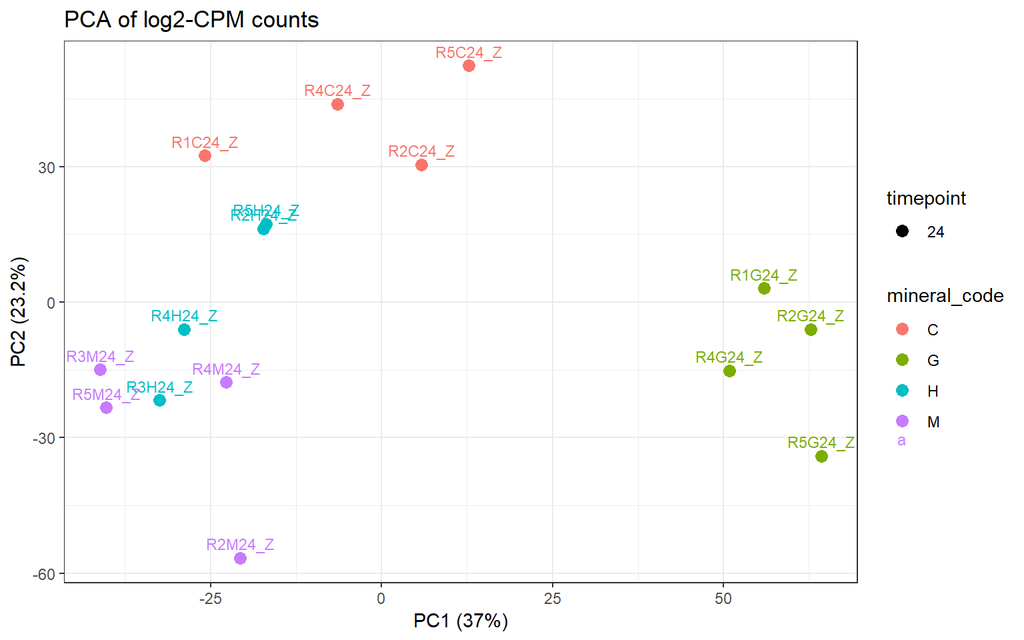

```r
# Filter out samples processed using DREX protocol and keep only samples at 24 h
read_counts_24h <- read_counts %>%
  dplyr::select(-ends_with("D")) %>%
  dplyr::select((matches("24_")))

# Create edgeR DGEList
dge <- DGEList(counts = read_counts_24h)

# Filter lowly expressed genes (keep genes with CPM>1 in at least 2 samples)
keep <- rowSums(cpm(dge) > 1) >= 2
dge <- dge[keep, , keep.lib.sizes = FALSE]

# Normalize for library size (TMM normalization)
dge <- calcNormFactors(dge)

# Log2 CPM transformation
logCPM <- cpm(dge, log = TRUE, prior.count = 1)  # log2(CPM + 1)



pca_res <- prcomp(t(logCPM))  # samples as rows
pca_scores <- as.data.frame(pca_res$x) %>%
  tibble::rownames_to_column("sample_pca")

pca_metadata <- sample_metadata %>%
  tibble::rownames_to_column("sample_pca")

pca_df <- pca_scores %>%
  dplyr::left_join(pca_metadata, by = "sample_pca")


# Calculate percent of variance explained
# Variance explained per PC
pca_var <- pca_res$sdev^2
pca_var_frac <- pca_var / sum(pca_var)

# Percent variance explained
pca_var_pct <- round(100 * pca_var_frac, 1)


ggplot(pca_df, aes(x = PC1, y = PC2,
                   color = mineral_code,
                   shape = timepoint)) +
  geom_point(size = 3) +
  geom_text(aes(label = sample_pca), vjust = -0.7, size = 3) +
  theme_bw() +
  labs(
    title = "PCA of log2-CPM counts",
    x = paste0("PC1 (", pca_var_pct[1], "%)"),
    y = paste0("PC2 (", pca_var_pct[2], "%)")
  )
```

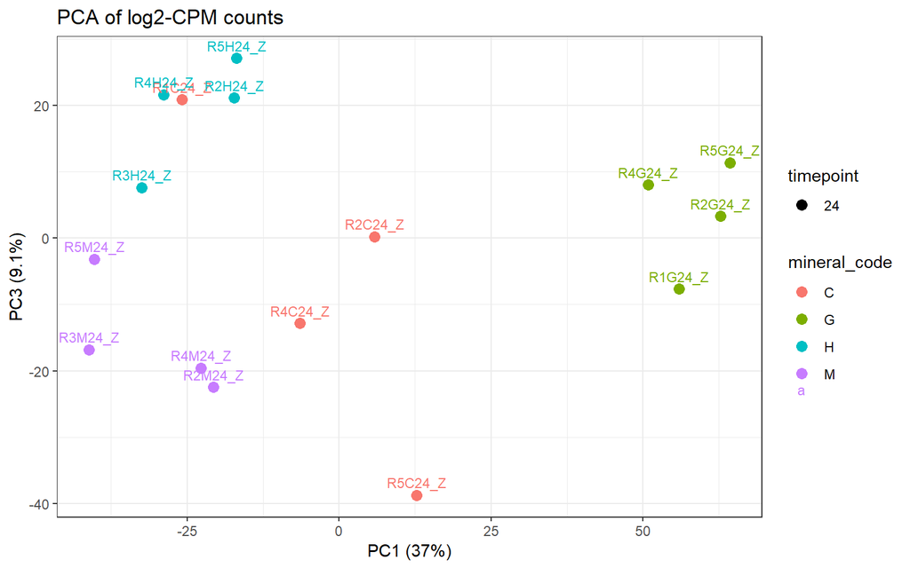

```r
ggplot(pca_df, aes(x = PC1, y = PC3,
                   color = mineral_code,
                   shape = timepoint)) +
  geom_point(size = 3) +
  geom_text(aes(label = sample_pca), vjust = -0.7, size = 3) +
  theme_bw() +
  labs(
    title = "PCA of log2-CPM counts",
    x = paste0("PC1 (", pca_var_pct[1], "%)"),
    y = paste0("PC3 (", pca_var_pct[3], "%)")
  )
```

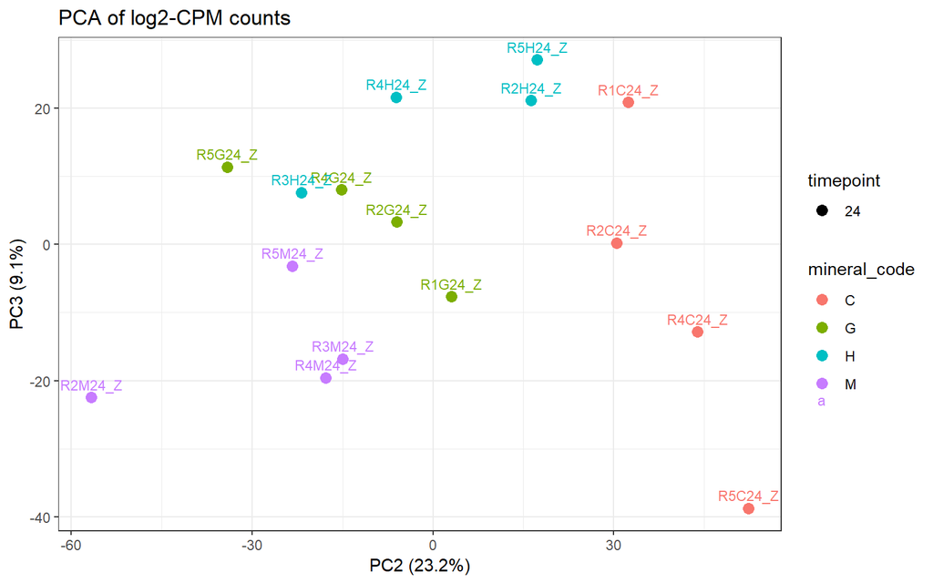

```r
ggplot(pca_df, aes(x = PC2, y = PC3,
                   color = mineral_code,
                   shape = timepoint)) +
  geom_point(size = 3) +
  geom_text(aes(label = sample_pca), vjust = -0.7, size = 3) +
  theme_bw() +
  labs(
    title = "PCA of log2-CPM counts",
    x = paste0("PC2 (", pca_var_pct[2], "%)"),
    y = paste0("PC3 (", pca_var_pct[3], "%)")
  )
```

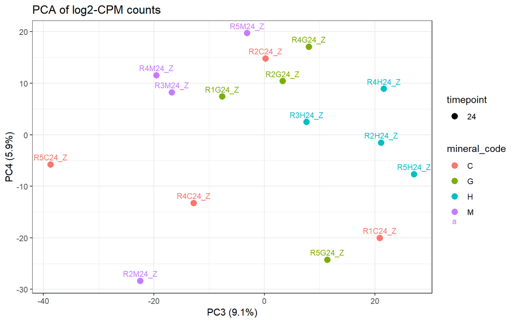

```r
ggplot(pca_df, aes(x = PC3, y = PC4,
                   color = mineral_code,
                   shape = timepoint)) +
  geom_point(size = 3) +
  geom_text(aes(label = sample_pca), vjust = -0.7, size = 3) +
  theme_bw() +
  labs(
    title = "PCA of log2-CPM counts",
    x = paste0("PC3 (", pca_var_pct[3], "%)"),
    y = paste0("PC4 (", pca_var_pct[4], "%)")
  )
```